# Conflict and coexistence between people and the world’s largest scavenger bird

# 6 Field observations of condor attacking livestock (aim 4)

Field observations will reveal little evidence of condor predation on live livestock. As such, perceived impacts are likely to exceed those supported by empirical evidence (Duriez *et al.* 2019, [Ballejo *et al.* 2020](https://doi.org/10.1016/j.biocon.2020.108627)).

The response variable is an multinomial ordinal (discrete categorical) of ascending severity scale:

```r
table(interactions$Interactions)
```

```
##
##  0  1  3
## 46  3  1
```

Although this type of data could be analyzed with ordinal regression, providing better results than with traditional count-based models (Poisson, Negative Binomial, Zero-Inflated Poisson, or Zero-Inflated Negative Binomial; see [Valle *et al.* 2019](https://www.nature.com/articles/s41598-019-39377-x)), the small sample size and sparseness of the data make the model to no converge (preliminary analyses not showed). We can group in a binomial response (presence/absence of interaction event), but identifying the “severity” of the interaction with colors in the figure. Let’s explore the potential responses.

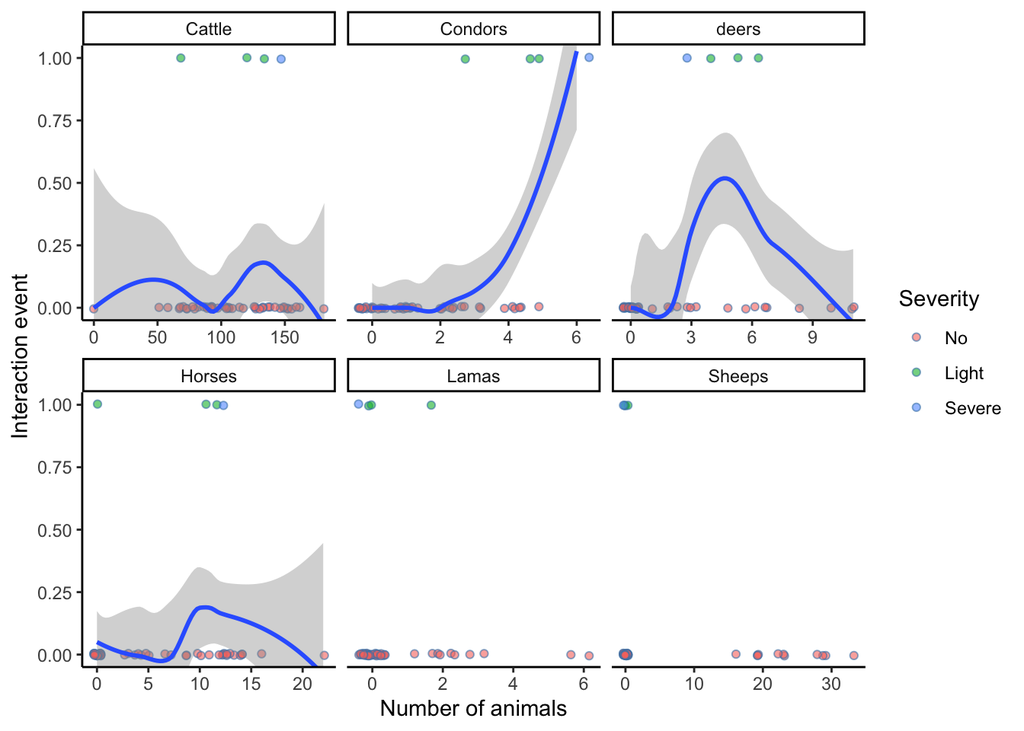

```r
interactions$Interactions_f <- factor(
  interactions$Interactions,
  levels = c(0,1,2,3),
  labels = c("No", "Light", "Moderate", "Severe")
)

interactions <- interactions |>
  mutate(Interactions_b = case_when(Interactions == 0 ~ 0,
                                    Interactions > 0 ~ 1))

interactions_long <- interactions %>%
  dplyr::select(Interactions_f, Interactions_b,
                N_Cattle, N_Horses, N_Sheeps, N_Lamas, N_deers, N_Condors) %>%
  pivot_longer(-c(Interactions_b, Interactions_f),
               names_to = "Variable",
               values_to = "Value") |>
  mutate(Variable = sub("*._","",Variable))

ggplot(interactions_long, aes(x = Value, y = as.integer(Interactions_b))) +
  geom_jitter(aes(fill = Interactions_f), height = 0.005, alpha = 0.6, color = "steelblue", shape = 21) +
  geom_smooth()+
  facet_wrap(~ Variable, scales = "free_x") +
  labs(x = "Number of animals", y = "Interaction event", fill = "Severity") +
  theme_classic() +
  coord_cartesian(ylim = c(0,1))
```

This LOESS trend by default in `ggplot` might help us to identify the potential models, discarding the number of lamas and sheeps. Nonetheless, we can compare the different models with AICc.

```r
mods_int_log <- list(
  null = glm(Interactions_b ~ 1, data = interactions, family = binomial),
  cattle = glm(Interactions_b ~ N_Cattle, data = interactions, family = binomial),
  condors = glm(Interactions_b ~ N_Condors, data = interactions, family = binomial),
  deers = glm(Interactions_b ~ N_deers, data = interactions, family = binomial),
  horses = glm(Interactions_b ~ N_Horses, data = interactions, family = binomial),
  lamas = glm(Interactions_b ~ N_Lamas, data = interactions, family = binomial),
  sheeps = glm(Interactions_b ~ N_Sheeps, data = interactions, family = binomial),
  # quadratic of cattle, deers, horses
  cattle.2 = glm(Interactions_b ~ N_Cattle + I(N_Cattle^2), data = interactions, family = binomial),
  deers.2 = glm(Interactions_b ~ N_deers + I(N_deers^2), data = interactions, family = binomial),
  horses.2 = glm(Interactions_b ~ N_Horses + I(N_Horses^2), data = interactions, family = binomial),
  global = glm(Interactions_b ~ N_Condors + N_deers + I(N_deers^2) + N_Cattle + I(N_Cattle^2) + N_Horses + I(N_Horses^2), data = interactions, family = binomial)
)
AICcmodavg::aictab(mods_int_log) # Condors and deers quadratic
```

```
##
## Model selection based on AICc:
##
##          K  AICc Delta_AICc AICcWt Cum.Wt     LL
## condors  2 17.41       0.00   0.54   0.54  -6.58
## deers.2  3 18.83       1.42   0.27   0.81  -6.15
## global   8 19.51       2.10   0.19   1.00   0.00
## null     1 29.96      12.55   0.00   1.00 -13.94
## sheeps   2 30.05      12.64   0.00   1.00 -12.90
## deers    2 30.12      12.71   0.00   1.00 -12.93
## horses   2 31.33      13.92   0.00   1.00 -13.54
## cattle   2 31.88      14.47   0.00   1.00 -13.81
## lamas    2 32.10      14.69   0.00   1.00 -13.92
## horses.2 3 33.03      15.62   0.00   1.00 -13.25
## cattle.2 3 34.05      16.64   0.00   1.00 -13.76
```

```r
summary(mods_int_log$condors) # clear relationship
```

```
##
## Call:
## glm(formula = Interactions_b ~ N_Condors, family = binomial,
##     data = interactions)
##
## Coefficients:
##             Estimate Std. Error z value Pr(>|z|)
## (Intercept)  -7.8327     3.1788  -2.464   0.0137 *
## N_Condors     1.6281     0.7302   2.230   0.0258 *
## ---
## Signif. codes:  0 '***' 0.001 '**' 0.01 '*' 0.05 '.' 0.1 ' ' 1
##
## (Dispersion parameter for binomial family taken to be 1)
##
##     Null deviance: 27.877  on 49  degrees of freedom
## Residual deviance: 13.155  on 48  degrees of freedom
## AIC: 17.155
##
## Number of Fisher Scoring iterations: 8
```

```r
summary(mods_int_log$deers.2) # trend
```

```
##
## Call:
## glm(formula = Interactions_b ~ N_deers + I(N_deers^2), family = binomial,
##     data = interactions)
##
## Coefficients:
##              Estimate Std. Error z value Pr(>|z|)
## (Intercept)  -17.6535    11.3821  -1.551    0.121
## N_deers        8.2953     5.4972   1.509    0.131
## I(N_deers^2)  -0.9193     0.6151  -1.495    0.135
##
## (Dispersion parameter for binomial family taken to be 1)
##
##     Null deviance: 27.877  on 49  degrees of freedom
## Residual deviance: 12.310  on 47  degrees of freedom
## AIC: 18.31
##
## Number of Fisher Scoring iterations: 10
```

As only 4 interaction events have been reported (out of 50; 46 no interactions), the coefficients, p-values, and uncertainty estimates from `glm()` could be unreliable. In addition, the global model reported a LL = 0, a red flag for separation and convergence. Due to these, we can try a Firth’s bias-reduced penalized-likelihood logistic regression.

```r
mods_int_logistf <- list(
  null = logistf(Interactions_b ~ 1, data = interactions, family = binomial),
  cattle = logistf(Interactions_b ~ N_Cattle, data = interactions, family = binomial),
  condors = logistf(Interactions_b ~ N_Condors, data = interactions, family = binomial),
  deers = logistf(Interactions_b ~ N_deers, data = interactions, family = binomial),
  horses = logistf(Interactions_b ~ N_Horses, data = interactions, family = binomial),
  lamas = logistf(Interactions_b ~ N_Lamas, data = interactions, family = binomial),
  sheeps = logistf(Interactions_b ~ N_Sheeps, data = interactions, family = binomial),
  # quadratic of cattle, deers, horses
  cattle.2 = logistf(Interactions_b ~ N_Cattle + I(N_Cattle^2), data = interactions, family = binomial),
  deers.2 = logistf(Interactions_b ~ N_deers + I(N_deers^2), data = interactions, family = binomial),
  horses.2 = logistf(Interactions_b ~ N_Horses + I(N_Horses^2), data = interactions, family = binomial),
  global = logistf(Interactions_b ~ N_Condors + N_deers + N_Cattle + N_Horses + N_Sheeps + N_Lamas, data = interactions, family = binomial)
)
aic_table_int <- lapply(mods_int_logistf, AICc_logistf)
aic_table_int <- do.call(rbind, aic_table_int)
aic_table_int <- aic_table_int |>
  mutate(dAICc = AICc - min(AICc)) |>
  arrange(dAICc)
aic_table_int # global
```

```
##                     AIC      AICc K     dAICc
## global.full    0.658666  3.325333 7  0.000000
## cattle.2.full  7.130349  7.652088 3  4.326755
## cattle.2.null  7.528356  8.050095 3  4.724762
## deers.2.full  13.410790 13.932530 3 10.607197
## condors.full  15.250538 15.505857 2 12.180525
## global.null   12.887140 15.553806 7 12.228474
## horses.2.full 17.788263 18.310002 3 14.984669
## horses.2.null 19.036165 19.557904 3 16.232572
## cattle.full   21.831529 22.086848 2 18.761516
## cattle.null   21.988983 22.244302 2 18.918970
## deers.2.null  22.743062 23.264801 3 19.939469
## sheeps.full   23.946122 24.201441 2 20.876109
## deers.full    24.463474 24.718793 2 21.393460
## sheeps.null   24.475216 24.730536 2 21.405203
## horses.full   24.690019 24.945338 2 21.620006
## horses.null   25.506177 25.761497 2 22.436164
## deers.null    26.781546 27.036865 2 23.711532
## condors.null  28.054793 28.310113 2 24.984780
## lamas.full    28.352564 28.607883 2 25.282550
## null.full     28.528430 28.611763 1 25.286431
## null.null     28.528430 28.611763 1 25.286431
## lamas.null    28.447016 28.702335 2 25.377003
```

```r
summary(mods_int_logistf$global)
```

```
## logistf(formula = Interactions_b ~ N_Condors + N_deers + N_Cattle +
##     N_Horses + N_Sheeps + N_Lamas, data = interactions, family = binomial)
##
## Model fitted by Penalized ML
## Coefficients:
##                      coef   se(coef)   lower 0.95 upper 0.95       Chisq
## (Intercept) -6.0418565298 2.61777246 -20.78100901 -1.1586197 7.096210424
## N_Condors    1.0627571083 0.42608705   0.26696937  3.8651712 8.663124146
## N_deers      0.3114756556 0.18403305  -0.08416514  1.1082451 2.332955888
## N_Cattle    -0.0007171924 0.01837667  -0.05272306  0.1215282 0.001059109
## N_Horses     0.0196891256 0.09111621  -0.44865986  0.2388104 0.032541637
## N_Sheeps     0.0448508838 0.11467648  -1.02459709  0.4184368 0.049772724
## N_Lamas     -0.0738176790 0.57779736  -1.78373350  5.2163892 0.006638915
##                       p method
## (Intercept) 0.007724711      2
## N_Condors   0.003247141      2
## N_deers     0.126661159      2
## N_Cattle    0.974038266      2
## N_Horses    0.856844045      2
## N_Sheeps    0.823459223      2
## N_Lamas     0.935060597      2
##
## Method: 1-Wald, 2-Profile penalized log-likelihood, 3-None
##
## Likelihood ratio test=12.22847 on 6 df, p=0.05706167, n=50
## Wald test = 13.11662 on 6 df, p = 0.04122089
```

The negative coefficient for the intercept (and CI also negative) indicate that at value 0 for all predictors (no condors, no livestock), there is no interaction. This is anchoring the model in a starting meaningful way for the covariates (although biologically unrealistic). In mathematical form:

$$\text{logit}(\alpha) = \beta_0 + \beta_i X_i \cdots$$
where $\alpha$ is the probability of an event to occur (interaction or no interaction), $\beta_0$ the intercept, while $\beta_i$ and $X_i$ are the slope and value for each covariate $i$, respectively. When all $X_i = 0$,
$$\beta_0 = \log \left( \frac{\alpha}{1-\alpha} \right); \\$$

and with an intercept $\approx -6.04$:
$$\alpha = \frac{e^{-6.04}}{1+e^{-6.04}} \approx 0.002$$

This indicates that when all the predictors have a count of 0 individuals, the predicted probability of an interaction is $0.2\%$ (this teeny tiny probability is biologically unrealistic, but mathematically useful to understand the effect of the other covariates).

The clearest relationship of the probability of occurring an interaction event is with the number of condors. Specifically, $\exp(1.063) \approx 2.89$, which means that each additional condor multiplies the odds of an interaction by almost 3 times.

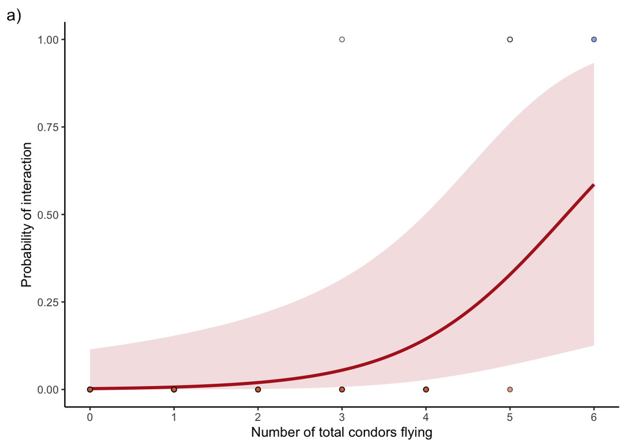

```r
newdat_int <- data.frame(
  N_Condors = seq(min(interactions$N_Condors),
                  max(interactions$N_Condors),
                  length = 100),
  N_deers = median(interactions$N_deers),
  N_Cattle = median(interactions$N_Cattle),
  N_Horses = median(interactions$N_Horses),
  N_Sheeps = median(interactions$N_Sheeps),
  N_Lamas = median(interactions$N_Lamas)
)

# linear predictors and standar error for 95% CI
pred_lp <- predict(mods_int_logistf$global, newdat_int, type = "link", se.fit = TRUE)
newdat_int$lp      <- pred_lp$fit
newdat_int$lp_low  <- pred_lp$fit - 1.96 * pred_lp$se.fit
newdat_int$lp_high <- pred_lp$fit + 1.96 * pred_lp$se.fit

# Convert to probabilities
newdat_int$pred      <- invlogit(newdat_int$lp)
newdat_int$pred_low  <- invlogit(newdat_int$lp_low)
newdat_int$pred_high <- invlogit(newdat_int$lp_high)


int_a <- ggplot(newdat_int, aes(x = N_Condors, y = pred)) +
  geom_ribbon(aes(ymin = pred_low, ymax = pred_high),
              fill = "firebrick", alpha = 0.15)+
  geom_line(size = 1.2, color = "firebrick") +
  geom_point(data = interactions |>
                dplyr::select(N_Condors,Interactions_b,Interactions_f),
             aes(y = Interactions_b, fill = Interactions_f),
             alpha = 0.6, shape = 21)+
  scale_fill_manual(values = met.brewer("OKeeffe1",n=3))+
  scale_y_continuous(limits = c(0,1))+
  scale_x_continuous(breaks = seq(0,6,1))+
  labs(x = "Number of total condors flying",
       y = "Probability of interaction",
       fill = "Severity",
       tag = "a)") +
  theme_classic()+
  theme(legend.position = "none")
int_a
```

Now we can include the demographics of the number of condors to see which class is driving the effect of Interactions ~ N_condors.

```r
# a list of models with penalized likelihood
mods_condor_classes <- list(
  null  = logistf(Interactions_b ~ 1,  data = interactions),
  juvF  = logistf(Interactions_b ~ N_juviCondorsFeme,  data = interactions),
  subF  = logistf(Interactions_b ~ N_subadCondorsFeme, data = interactions),
  adF   = logistf(Interactions_b ~ N_adultCondorsFeme, data = interactions),
  juvM  = logistf(Interactions_b ~ N_juviCondorsMale,  data = interactions),
  subM  = logistf(Interactions_b ~ N_subadCondorsMale, data = interactions),
  adM   = logistf(Interactions_b ~ N_adultCondorsMale, data = interactions)
)

# estimate AICc for penalized likelihood
AICc_logistf <- function(model) {
  ll <- model$loglik  # penalized log-likelihood (implemented in logistf)
  K  <- length(model$coef)  # number of parameters
  n  <- model$n  # sample size

  AIC  <- -2 * ll + 2 * K # AIC formula
  AICc <- AIC + (2 * K * (K + 1)) / (n - K - 1) # small sample correction

  return(data.frame(AIC = AIC, AICc = AICc, K = K))
}

# construct AIC table
aic_table_condors <- lapply(mods_condor_classes, AICc_logistf)
aic_table_condors <- do.call(rbind, aic_table_condors)
aic_table_condors <- aic_table_condors |>
  mutate(dAICc = AICc - min(AICc)) |>
  arrange(dAICc)
aic_table_condors
```

```
##                AIC     AICc K     dAICc
## juvF.full 22.30984 22.56516 2 0.0000000
## adM.full  23.21904 23.47436 2 0.9092059
## adF.full  25.99728 26.25260 2 3.6874455
## null.full 28.52843 28.61176 1 6.0466080
## null.null 28.52843 28.61176 1 6.0466080
## juvF.null 29.41670 29.67202 2 7.1068654
## juvM.full 29.72430 29.97962 2 7.4144620
## subF.full 29.80804 30.06336 2 7.4982034
## adM.null  29.89912 30.15444 2 7.5892806
## adF.null  30.14573 30.40105 2 7.8358909
## subM.full 30.66149 30.91681 2 8.3516536
## subM.null 31.01030 31.26562 2 8.7004604
## juvM.null 31.27212 31.52744 2 8.9622828
## subF.null 31.70616 31.96148 2 9.3963212
```

Two models are identified as the better among these demographics classes: Number of flying juvenile female condors and number of adult male flying condors.

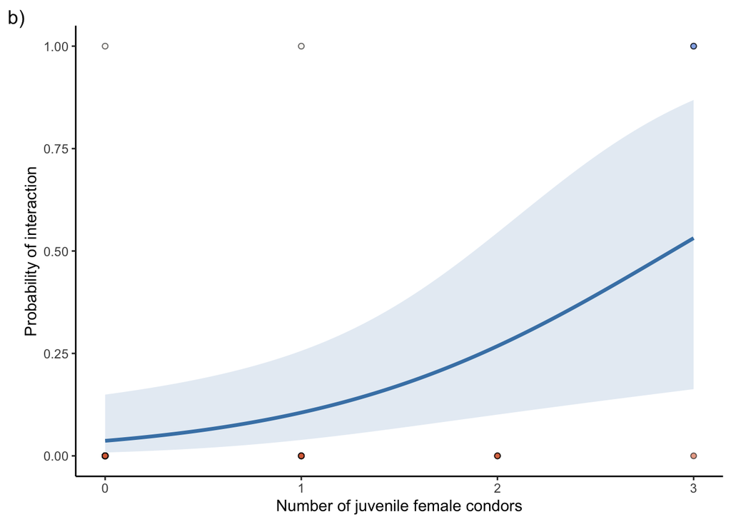

```r
mod_juvF <- mods_condor_classes$juvF
mod_adM  <- mods_condor_classes$adM

newdat_juvF <- data.frame(
  N_juviCondorsFeme = seq(min(interactions$N_juviCondorsFeme),
                          max(interactions$N_juviCondorsFeme),
                          length = 100)
  )

newdat_adM <- data.frame(
  N_adultCondorsMale = seq(min(interactions$N_adultCondorsMale),
                           max(interactions$N_adultCondorsMale),
                           length = 100)
)

make_pred_df <- function(model, newdata, xvar) {

  pred_lp <- predict(model, newdata, type = "link", se.fit = TRUE)

  newdata$lp      <- pred_lp$fit
  newdata$lp_low  <- pred_lp$fit - 1.96 * pred_lp$se.fit
  newdata$lp_high <- pred_lp$fit + 1.96 * pred_lp$se.fit

  invlogit <- function(x) exp(x) / (1 + exp(x))

  newdata$pred      <- invlogit(newdata$lp)
  newdata$pred_low  <- invlogit(newdata$lp_low)
  newdata$pred_high <- invlogit(newdata$lp_high)

  newdata$xvar <- newdata[[xvar]]

  return(newdata)
}

pred_juvF <- make_pred_df(mod_juvF, newdat_juvF, "N_juviCondorsFeme")
pred_adM  <- make_pred_df(mod_adM,  newdat_adM,  "N_adultCondorsMale")

int_b <- ggplot(pred_juvF, aes(x = xvar, y = pred)) +
  geom_ribbon(aes(ymin = pred_low, ymax = pred_high),
              fill = "steelblue", alpha = 0.15) +
  geom_line(size = 1.2, color = "steelblue") +
  geom_point(data = interactions,
             aes(x = N_juviCondorsFeme, y = Interactions_b, fill = Interactions_f),
             alpha = 0.6, shape = 21) +
  scale_y_continuous(limits = c(0,1)) +
  scale_fill_manual(values = met.brewer("OKeeffe1",n=3))+
  labs(x = "Number of juvenile female condors",
       y = "Probability of interaction",
       fill = "Severity",
       tag = "b)") +
  theme_classic()+
  theme(legend.position = "none")
int_b
```

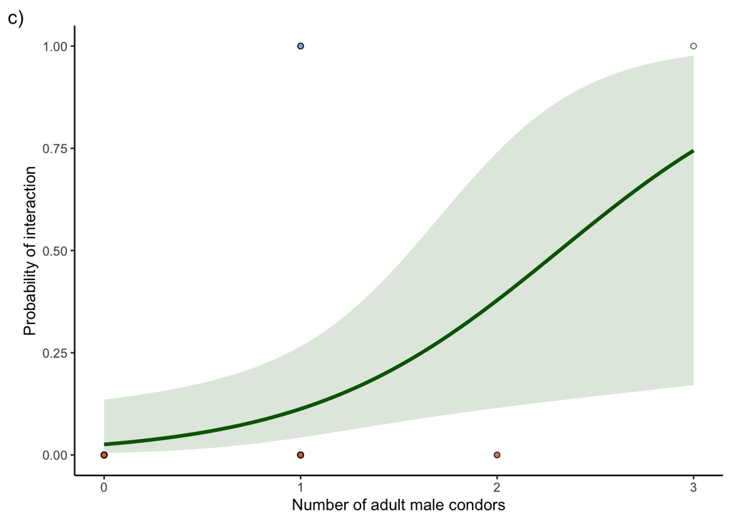

```r
int_c <- ggplot(pred_adM, aes(x = xvar, y = pred)) +
  geom_ribbon(aes(ymin = pred_low, ymax = pred_high),
              fill = "darkgreen", alpha = 0.15) +
  geom_line(size = 1.2, color = "darkgreen") +
  geom_point(data = interactions,
             aes(x = N_adultCondorsMale, y = Interactions_b, fill = Interactions_f),
             alpha = 0.6, shape = 21) +
  scale_y_continuous(limits = c(0,1)) +
  scale_fill_manual(values = met.brewer("OKeeffe1",n=3))+
  labs(x = "Number of adult male condors",
       y = "Probability of interaction",
       fill = "Severity",
       tag = "c)") +
  theme_classic() +
  theme(legend.position = "none")
int_c
```

And combine the figure

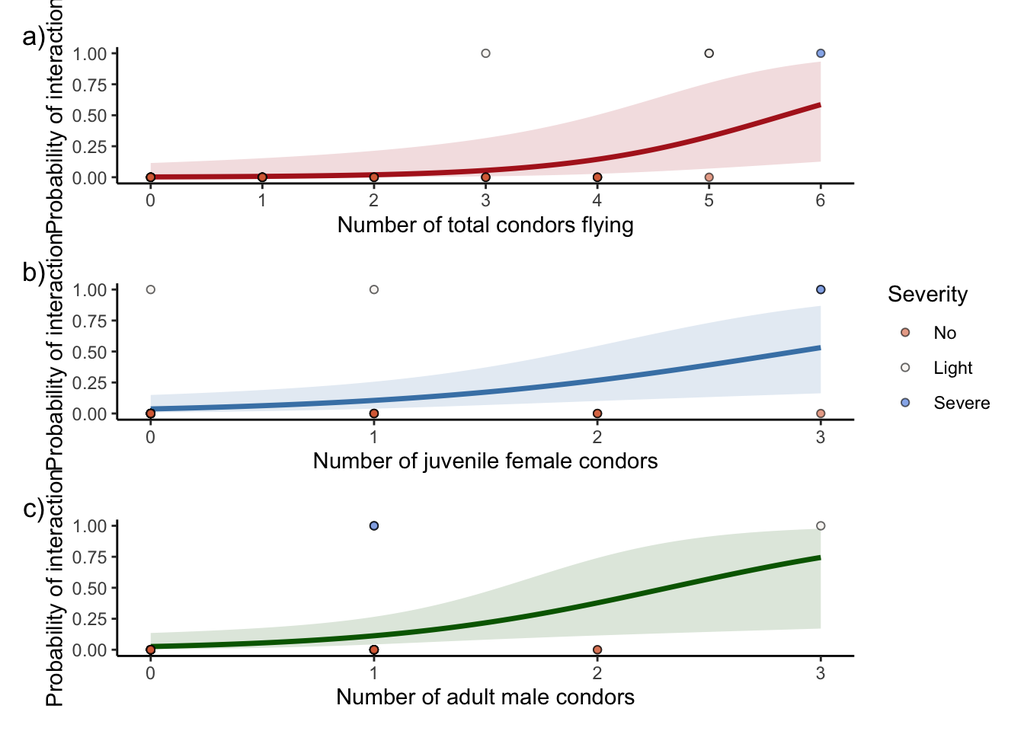

```r
(int_a / int_b / int_c) +
  plot_layout(guides = "collect") +
  theme(
    legend.position = "bottom",
    legend.direction = "vertical"
  )
```

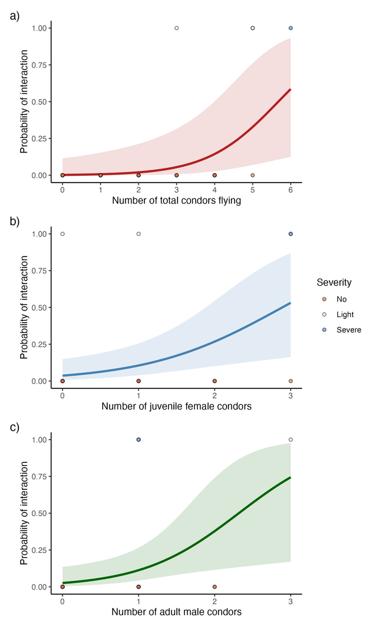

**Condor-livestock interactions.** Predicted probability of condor-livestock interactions as a function of number of condor flying (a), whit the number of juvenile females (b) and adult males (c) showing the demographic groups with clearest relationship. The few interactions (4, only 1 severe) were not related with livestock availability, contrary to farmers perceptions.

```r
ggsave(filename = "figs/Fig_Aim3_Condor_livestock_interaction.jpg", dpi = 300,
       width = 150, height = 250, units = "mm")
```